# Login to remote server without typing password (on Windows)

Ji Huang

2019-11-19

This post is to show you how to login to remote server without typing password every time. This is powered by [SSH-Key](https://www.ssh.com/ssh/key/). On windows, you can use [Putty](https://www.chiark.greenend.org.uk/~sgtatham/putty/) to generate SSH Keys.

# 1. Download and install the Putty Suit

Putty is still my favorite SH client, stable and lightweight. It has all the functions I need from a SSH client. You can simply download from [Putty website](https://www.chiark.greenend.org.uk/~sgtatham/putty/latest.html). Be sure to install the *Package* since you will need the *PuTTYgen* for generating the SSH-key.

# 2. Generate SSH Key

To generate SSH Key, simply opne *PuTTYgen* and click *Generate*.

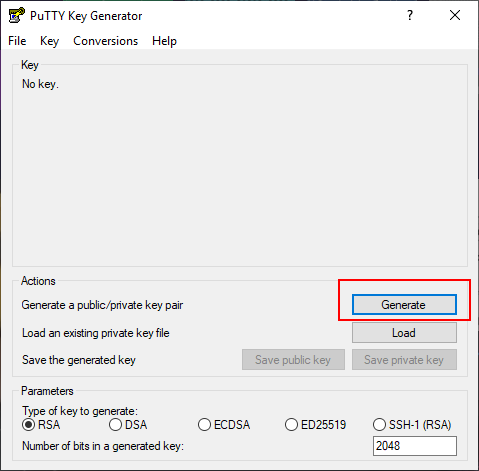

After 5s, they key is generated like one below. Simple click *Save private key* and save it in a secure location in your computer. You can assign *Key passphrase* which is basically a password to increase security. However, if you set *key passphrase*, you will need to type it everytime when login to the server.

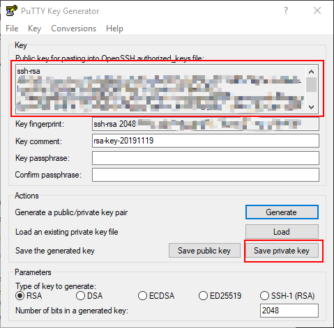

# 3. Set up the server

To set up the server, copy the SSH key from the red box and paste it to the `.ssh/authorized_keys` file. On sever, you can edit the file by `vim`: `vim ~/.ssh/authorized_keys`.

# 4. Set up local PuTTY

Load you server from PuTTY and Click *SSH–Auth* on the left panel. Load the saved SSH Key file from Step 2.

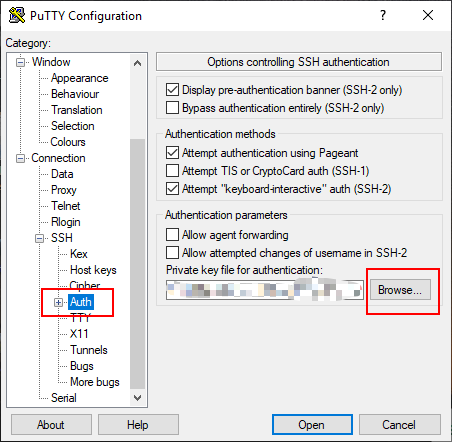

Go back to your *Session* and save the setting.

**Now you are good to go!**

Bonus: If you use SFTP/FTP add-in in Sublime Text, you can simple set up the sever by pointing to the same SSH Key file.